# Week 2 Problem Sheet

Akasha Strub

05 July 2023

## Import libraries

```r
# Import libraries
library(rethinking)
library(dplyr)
library(ggplot2)
library(dagitty)

# Set seed
set.seed(0507)
```

## Problem 1

### Part 1

From the Howell1 dataset, consider only the people younger than 13 years old. Assume that age influences weight through two paths. First, age influences height, and height influences weight. Second, age directly influences weight through age related changes in muscle growth and body proportions. Draw the DAG that represents these causal relationships.

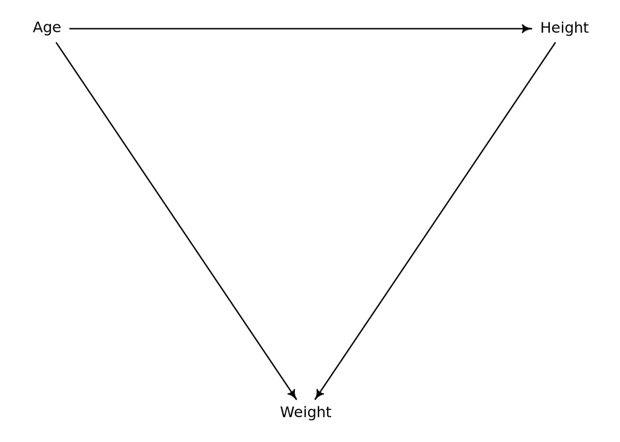

```r
# Draw DAG
dag <- dagitty( "dag {
Age -> Height
Height -> Weight
Age -> Weight
}")

coordinates(dag) <- list(
  x = c(Age = 0, Height = 2, Weight = 1) ,
  y = c(Age = 0, Height = 0, Weight = 1))

drawdag(dag)
```

### Part 2

Write a generative simulation that takes age as an input and simulates height and weight, obeying the relationships in the DAG.

```r
# Import Howell1 dataset
data(Howell1)

# Filter to people younger than 13
df <- Howell1 %>%
  filter(age < 13)

# Standardize data
df1 <- df %>%
  mutate(age_std = standardize(age),
         weight_std = standardize(weight),
         height_std = standardize(height))

# Find association between age and height to generate height as function of age
model1a <- quap(
  alist(
    height_std ~ dnorm(mu, sigma),
    mu <- a + b*age_std,
    a ~ dnorm( 0 , 1 ),
    b ~ dnorm( 0 , 1 ),
    sigma ~ dexp( 1 )
    ),
  data = df1)

# These posterior distribution estimates will be used for the generative model
# to generate height from age
precis(model1a)
```

```
##                mean         sd        5.5%      94.5%
## a     -1.853265e-06 0.03261100 -0.05212053 0.05211683
## b      9.172046e-01 0.03272334  0.86490639 0.96950284
## sigma  3.942499e-01 0.02302460  0.35745217 0.43104770
```

```r
# Find association between weight and age & height to generate weight as a function of age and height
model1b <- quap(
  alist(
    weight_std ~ dnorm(mu, sigma),
    mu <- a + b_age*age_std + b_height*height_std,
    a ~ dnorm( 0 , 1 ),
    b_age ~ dnorm( 0 , 1 ),
    b_height ~ dnorm( 0 , 1 ),
    sigma ~ dexp( 1 )
    ),
  data = df1)

# These posterior distribution estimates will be used for the generative model
# to generate weight from age and height
precis(model1b)
```

```
##                  mean         sd        5.5%      94.5%
## a        3.045946e-07 0.02133176 -0.03409197 0.03409258
## b_age    6.696153e-02 0.05390249 -0.01918506 0.15310811
## b_height 9.036599e-01 0.05390262  0.81751306 0.98980667
## sigma    2.578113e-01 0.01506681  0.23373167 0.28189101
```

```r
# Instantiate range of age values
age_std1 <- seq(-2, 2, length.out = 100)

# Model height as as function of age
height_std1 <- rnorm(0 + 0.92 * age_std1, 0.39)

# Model weight as a function of age and height
weight_std1 <- rnorm(0 + 0.07 * age_std1 + 0.90 * height_std1, 0.26)
```

### Part 3

Estimate the causal association between age and weight.

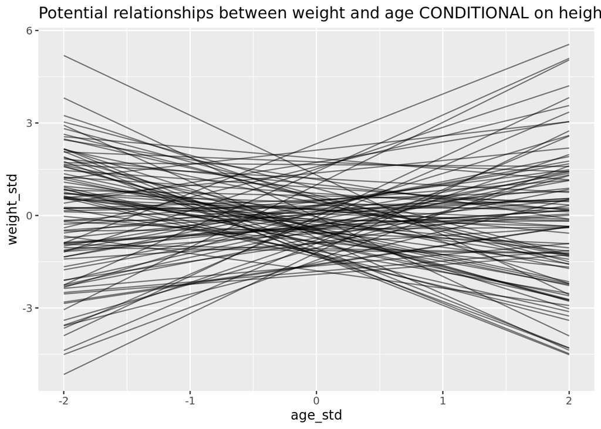

```r
# For the direct causal association, height should be included to find the direct effect
# of age on weight, for a fixed height. A multivariate regression is to be run (Gaussian
# approximation of posterior will be used, as opposed to grid/MCMC)

# Create model for weight as a function on age
model2 <- quap(
  alist(
    weight_std ~ dnorm(mu, sigma),
    mu <- a + b_age*age_std + b_height*height_std,
    a ~ dnorm( 0 , 1 ),
    b_age ~ dnorm( 0 , 1 ),
    b_height ~ dnorm( 0 , 1 ),
    sigma ~ dexp( 1 )
    ),
  data = df1)

# Investigate validity of priors via prior predictive simulation
# Method 1 - plot relationships as lines for weight vs age and weight vs height
n_priors2 <- 100
prior_samples2a <- extract.prior(model2, n = n_priors2) %>%
  as.data.frame() %>%
  mutate(line = row_number())

df_plot2a <- expand.grid(line = seq(1:n_priors2),
                        age_std = seq(-2, 2)) %>%
  left_join(prior_samples2a, by = "line") %>%
  mutate(weight_std = a + b_age*age_std) %>%
  arrange(line, age_std)

# Plot
ggplot(data = df_plot2a, aes(x = age_std, y = weight_std, group = line)) +
  geom_line(alpha = 0.5) +
  labs(title = "Potential relationships between weight and age CONDITIONAL on height (from prior)")
```

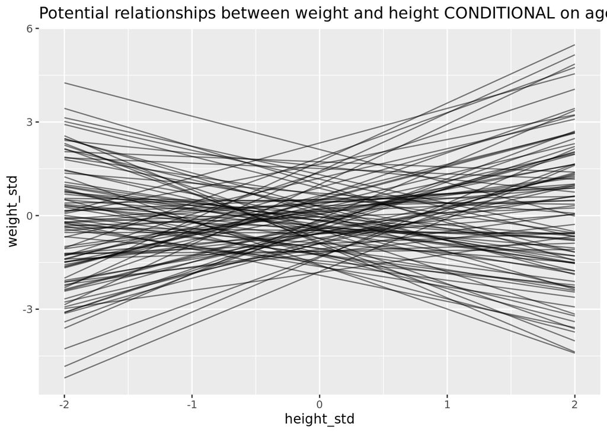

```r
df_plot2b <- expand.grid(line = seq(1:n_priors2),
                        height_std = seq(-2, 2)) %>%
  left_join(prior_samples2a, by = "line") %>%
  mutate(weight_std = a + b_height*height_std) %>%
  arrange(line, height_std)

# Plot
ggplot(data = df_plot2b, aes(x = height_std, y = weight_std, group = line)) +
  geom_line(alpha = 0.5) +
  labs(title = "Potential relationships between weight and height CONDITIONAL on age (from prior)")
```

```r
# An additional prior predictive method for the multivariate regression use case
# could be to simulate predictions from prior distributions and compare to raw data
# (this is less relevant for prior distributions as the points would be all over the place.
# It is much more relevant for posterior distributions to evaluate model fit)

# See marginal posterior distributions
precis(model2)
```

```
##                  mean         sd        5.5%      94.5%
## a        7.598427e-08 0.02133188 -0.03409239 0.03409255
## b_age    6.700612e-02 0.05390281 -0.01914099 0.15315322
## b_height 9.035992e-01 0.05390296  0.81745187 0.98974656
## sigma    2.578128e-01 0.01506702  0.23373279 0.28189281
```

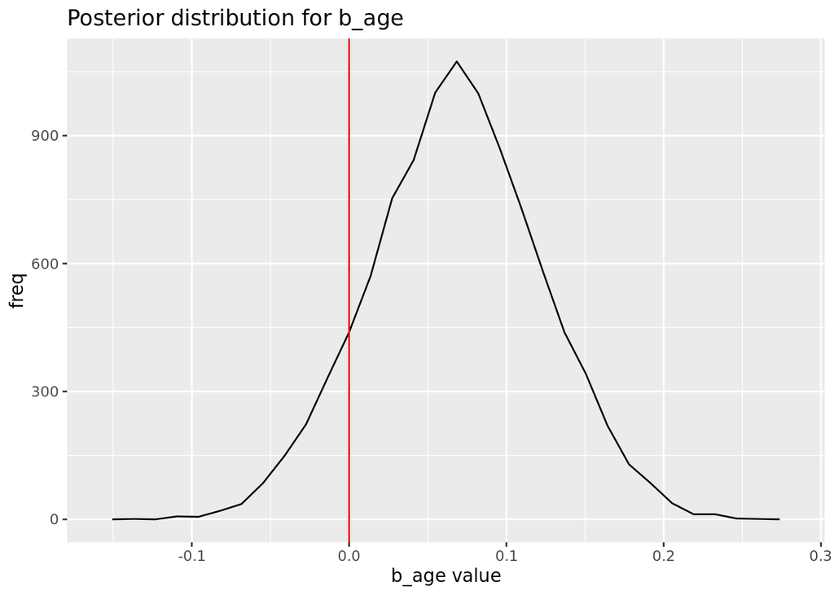

```r
# b_age is close to 0 and overlaps heavily with 0. Therefore CONDITIONAL on height,
# can can conclude that the DIRECT causal effect of age on height is minimal.
# This makes sense intuitively. If a child grows older but does not grow in height,
# we would estimate that their weight would remain somewhat constant.
# And therefore that the direct causal effect be small.
# The mean of 0.07 SD results in 0.1kg/year... "clinically insignificant" regardless
ggplot() +
  geom_freqpoly(aes(x = extract.samples(model2, n = 10000)$b_age), stat = "bin") +
  geom_vline(aes(xintercept = 0), colour = "red") +
  labs(x = "b_age value",
       y = "freq",
       title = "Posterior distribution for b_age")
```